# Using Copilot (Basic) to create a map

### Looking at your screenshot

I would also immediately make these changes:

```r
draw_plot(
  zoom_map,
  x = 0.04,
  y = 0.18,
  width = 0.30,
  height = 0.30
)
```

and

```r
draw_plot(
  vic_inset,
  x = 0.73,
  y = 0.50,
  width = 0.24,
  height = 0.24
)
```

Those positions are much closer to the original QGIS layout shown in your example.

There are still a few more issues around text and inset locations.

[figure not shown]

The map that was saved through the updated process

There are obviously a few issues, like: - none of the labels being produced in a readable fashion; and, - the insets are in weird places.

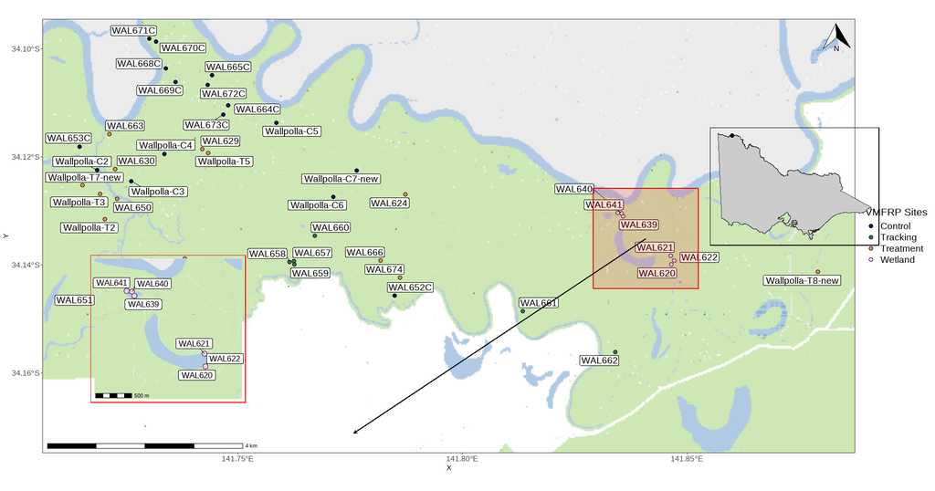

What was produced in R

While most of the issues are still present, it is clear that the `R` version does have the labels, and they are lost in the process of saving the image.

### download_spatial_data.R

```r
# ============================================================
# VMFRP Wallpolla Map Setup
#
# Downloads and caches:
#   1. Vicmap Basemap (Cartographic, VicGrid2020)
#   2. Victoria administrative boundary
#
# Outputs:
#   data/spatial/vicmap_topographic/vicmap_wallpolla.tif
#   data/spatial/victoria_boundary.gpkg
#
# ============================================================

library(sf)
library(terra)
library(dplyr)
library(geodata)

# ------------------------------------------------------------
# Settings
# ------------------------------------------------------------

buffer_distance <- 5000  # metres

dir.create(
  "data/spatial/vicmap_topographic",
  recursive = TRUE,
  showWarnings = FALSE
)

# ------------------------------------------------------------
# Load site data
# ------------------------------------------------------------

message("Reading site data...")

sites <- st_read(
  "data/spatial/vmfrp_wallpolla_veg.gpkg",
  quiet = TRUE
)

sites <- st_transform(sites, 7899)

# ------------------------------------------------------------
# Calculate study area extent
# ------------------------------------------------------------

message("Calculating extent...")

study_extent <- st_buffer(
  st_union(sites),
  dist = buffer_distance
)

bb <- st_bbox(study_extent)

e <- ext(
  bb["xmin"],
  bb["xmax"],
  bb["ymin"],
  bb["ymax"]
)

# ------------------------------------------------------------
# Download Victoria boundary
# ------------------------------------------------------------

boundary_file <- "data/spatial/victoria_boundary.gpkg"

if (!file.exists(boundary_file)) {

  message("Downloading Australian administrative boundaries...")

  aus_states <- geodata::gadm(
    country = "AUS",
    level = 1,
    path = tempdir()
  )

  aus_states_sf <- sf::st_as_sf(aus_states)

  vic <- aus_states_sf |>
    dplyr::filter(NAME_1 == "Victoria") |>
    sf::st_transform(7899)

  sf::st_write(
    vic,
    boundary_file,
    delete_dsn = TRUE,
    quiet = TRUE
  )

  message("Victoria boundary saved.")

} else {

  message("Victoria boundary already present.")

}

# ------------------------------------------------------------
# Connect to Vicmap WMTS
# ------------------------------------------------------------

message("Connecting to Vicmap WMTS...")

vicmap <- rast(
  paste0(
    "WMTS:",
    "https://base.maps.vic.gov.au/service",
    "?service=WMTS",
    "&request=GetCapabilities",
    ",layer=CARTO_VG2020"
  )
)

# ------------------------------------------------------------
# Crop to study area
# ------------------------------------------------------------

message("Downloading required map tiles...")

basemap <- crop(
  vicmap,
  e,
  snap = "out"
)

target_res <- 5

basemap_small <- terra::resample(
  basemap,
  terra::rast(
    ext = terra::ext(basemap),
    resolution = target_res,
    crs = crs(basemap)
  ),
  method = "near"
)

# ------------------------------------------------------------
# Save local cache
# ------------------------------------------------------------

outfile <- file.path(
  "data/spatial/vicmap_topographic",
  "vicmap_wallpolla.tif"
)

message("Writing GeoTIFF cache...")

writeRaster(
  basemap_small,
  outfile,
  overwrite = TRUE,
  gdal = c(
    "COMPRESS=DEFLATE",
    "PREDICTOR=2"
  )
)

message("Completed.")

message(paste("Cached basemap:", outfile))
```